# Assignment 1 Joel George - 33143390

## Task A: Data Wrangling and Analysis

### A1. Data Wrangling

##### Question 1

```python
import pandas as pd

df = pd.read_csv('Student_List_A2.csv')
# Pints the columns of the CSV and converts tem to a list
print("Column Names: \n", df.columns.tolist())
```

```
Column Names:
 ['StudentID', 'Age', 'StudyTimeWeekly', 'Absences', 'ParentalSupport', 'GPA', 'GradeClass']
```

##### Question 2

```python
grade_mapping = {
    0 : 'A',
    1 : 'B',
    2 : 'C',
    3 : 'D',
    4 : 'F'
}

df['GradeClass']= df['GradeClass'].map(grade_mapping)

print("Updated DataFrame with GradeClass:")
print(df.GradeClass)
```

```
Updated DataFrame with GradeClass:
0       B
1       F
2       D
3       F
4       B
       ..
2095    B
2096    A
2097    C
2098    B
2099    B
Name: GradeClass, Length: 2100, dtype: object
```

##### Question 3

```python
print("The missing values before:")
print(df.isnull().sum())
```

```
The missing values before:
StudentID           0
Age                 0
StudyTimeWeekly    21
Absences            0
ParentalSupport     0
GPA                 0
GradeClass          0
dtype: int64
```

```python
study_time_median = df['StudyTimeWeekly'].median()
print(f"The median of StudyTimeWeekly: {study_time_median}")
df['StudyTimeWeekly'].fillna(study_time_median, inplace=True)

print("The missing values after:")
print(df.isnull().sum())
```

```
The median of StudyTimeWeekly: 9.513100618
The missing values after:
StudentID          0
Age                0
StudyTimeWeekly    0
Absences           0
ParentalSupport    0
GPA                0
GradeClass         0
dtype: int64
```

##### Question 4

```python
print("Rows with problematic 'Absences':")
problem_rows = df[(df['Absences'] < 0) | (df['Absences'] > 100)]
print(problem_rows)

# Create a new DataFrame with 'Absences' between 0 and 100
df = df[(df['Absences'] >= 0) & (df['Absences'] <= 100)].copy()
# if this block is run again then no problematic rows will be found
```

```
Rows with problematic 'Absences':
      StudentID  Age  StudyTimeWeekly  Absences  ParentalSupport       GPA  \
112        1114   16        16.849282       320                1  1.919956
1001       2003   15         0.806505      -122                3  3.201710

     GradeClass
112           F
1001          B
```

Realistically this problem woyuld occur most likely during entry. The -122 value and the 320 value is too low and too high to actually be a part of the data set respectively. The negative value you cannot be negative days absent and the value 320 you cannot be absent for a longer period than the acual number of days of school. So in this instance the most probable cause for these outliers is due to data entry mistake.

##### Question 5

```python
def gpa_to_grade(gpa):
    if gpa >= 3.5:
        return 'A'
    elif 3.0 <= gpa < 3.5:
        return 'B'
    elif 2.5 <= gpa < 3.0:
        return 'C'
    elif 2.0 <= gpa < 2.5:
        return 'D'
    else:
        return 'F'

df['CorrectGradeClass'] = df['GPA'].apply(gpa_to_grade)

inconsistencies = df[df['GradeClass'] != df['CorrectGradeClass']]

print("Inconsistencies found:")
print(f"Total count: {len(inconsistencies)}")
print("Example StudentIDs of the inconsistencies:")
print(inconsistencies['StudentID'].tolist())

df['GradeClass'] = df['CorrectGradeClass']

inconsistencies = df[df['GradeClass'] != df['CorrectGradeClass']]

print("\nRe-audit for inconsistencies:")
print(f"Total count: {len(inconsistencies)}")
```

```
Inconsistencies found:
Total count: 100
Example StudentIDs of the inconsistencies:
[3182, 3183, 3189, 3193, 3195, 3199, 3202, 3206, 3208, 3210, 3212, 3214, 3215, 3216, 3217, 3220, 3221, 3222, 3226, 3227, 3228, 3229, 3233, 3236, 3238, 3240, 3241, 3242, 3243, 3248, 3251, 3252, 3253, 3255, 3256, 3258, 3259, 3263, 3264, 3265, 3267, 3270, 3274, 3275, 3276, 3277, 3278, 3282, 3283, 3285,…

Re-audit for inconsistencies:
Total count: 0
```

I have decided to trust the GPA column as the correct source of information. From analysing the CSV the GPA is a numerical raw score and is less prone to be entered through mistakenly and end up with the wrong value. Whereas the Grade class is a derived data point that comes from the GPA. Further analysis and calculations has to be made in order to obtain the Grade class and is more prone to it being a data entry mistake. Terefore the GPA column is more reliable than the Grade Class Column

### A2. Data Exploration and Visualisation

##### Question 1

```python
grade_percentage = df['GradeClass'].value_counts(normalize=True) * 100
rounded_percentage = grade_percentage.round(2)
print("Percentage of students in each GradeClass:")
print(rounded_percentage)
```

```
Percentage of students in each GradeClass:
GradeClass
F    53.62
D    17.59
C    16.16
B     9.72
A     2.91
Name: proportion, dtype: float64
```

##### Question 2 & 3

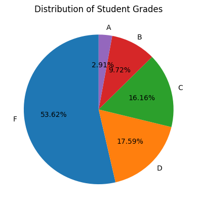

```python
import matplotlib.pyplot as plt

grade_counts = df['GradeClass'].value_counts()
plt.figure()
plt.pie(grade_counts, labels=grade_counts.index, autopct='%1.2f%%', startangle=90)
plt.title('Distribution of Student Grades')
plt.show()
```

When comparing the percentages they are exactly the same

##### Question 4

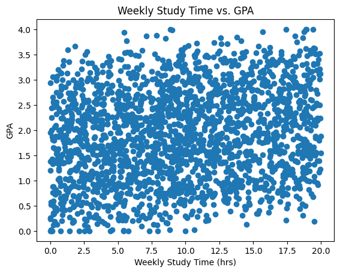

```
Correlation between Weekly Study Time and GPA: 0.1790583119758245
```

```python
# Create a scatterplot to visualize the relationship
plt.figure()
plt.scatter(df['StudyTimeWeekly'], df['GPA'])
plt.title('Weekly Study Time vs. GPA')
plt.xlabel('Weekly Study Time (hrs)')
plt.ylabel('GPA')
plt.show()

# Calculate the correlation coefficient
correlation = df['StudyTimeWeekly'].corr(df['GPA'])

print(f"Correlation between Weekly Study Time and GPA: {correlation}")
```

The correlation coefficeent of 0.179 is positive and close to 0, this suggests that as weekly study time increases, there is a slight chance for a student's GPA to also increase. However, because the value is weak, weekly study time is not a reliable predictor of GPA.

##### Question 5

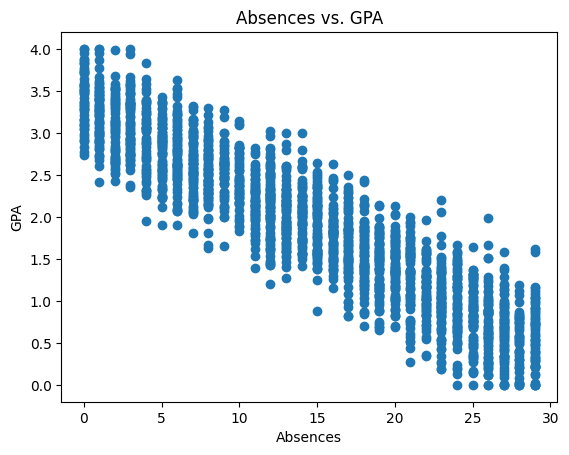

```
Correlation between Absences and GPA: -0.9197788569386012
```

```python
plt.figure()
plt.scatter(df['Absences'], df['GPA'])
plt.title('Absences vs. GPA')
plt.xlabel('Absences')
plt.ylabel('GPA')
plt.show()

correlation = df['Absences'].corr(df['GPA'])

print(f"Correlation between Absences and GPA: {correlation}")
```

The correlation coefficeent of -0.9198 is negative and close to -1, this suggests that as Absences increases, there is a high chance for a student's GPA to also decrease. Due to the coefficient correlation being closer toe -1 Abscenses is a highly reliable predictor of GPA.

##### Question 6

The correlation does not imply or indicate the causation of a dataset. While the dataset above is shown to have a very strong negative correlation between absences and GPA, it is not enough to to prove that the absences is the direct cause of lower GPAS. There might be a third varaible that may be impacting the GPA greater than absences. The correlation coefficent is just the strength and direction of the linear relationship between two variables and causation cannot be derived from it. Additoonal data to get an accurate causation would include factors like students' health, socioeconomic status, and overall engagement.

##### Question 7

```python
iqr = lambda x: x.quantile(0.75) - x.quantile(0.25)

# Group by 'GradeClass' and aggregate
aggregated_data = df.groupby('GradeClass').agg({'GPA': ['mean', 'median', 'std', iqr], 'Absences': ['mean', 'median', 'std', iqr]})
print(aggregated_data)
```

```
                 GPA                                  Absences         \
                mean    median       std <lambda_0>       mean median
GradeClass
A           3.681490  3.618273  0.163589   0.275281   1.475410    1.0
B           3.227285  3.219432  0.143109   0.242832   3.308824    3.0
C           2.732964  2.723828  0.145818   0.250655   6.433628    6.0
D           2.249837  2.240924  0.137388   0.230745  11.140921   11.0
F           1.181513  1.234141  0.513394   0.788061  21.008000   21.0


                 std <lambda_0>
GradeClass
A           1.659383        3.0
B           2.500782        4.0
C           3.562318        5.0
D           3.783787        6.0
F           5.033246        8.0
```

##### Question 8

```python
# Manually define a list of new column names in the correct order
new_col_names = ['GPA_mean', 'GPA_median', 'GPA_std', 'GPA_iqr','Absences_mean', 'Absences_median', 'Absences_std', 'Absences_iqr']
aggregated_data.columns = new_col_names

print(aggregated_data)
```

```
            GPA_mean  GPA_median   GPA_std   GPA_iqr  Absences_mean  \
GradeClass
A           3.681490    3.618273  0.163589  0.275281       1.475410
B           3.227285    3.219432  0.143109  0.242832       3.308824
C           2.732964    2.723828  0.145818  0.250655       6.433628
D           2.249837    2.240924  0.137388  0.230745      11.140921
F           1.181513    1.234141  0.513394  0.788061      21.008000

            Absences_median  Absences_std  Absences_iqr
GradeClass
A                       1.0      1.659383           3.0
B                       3.0      2.500782           4.0
C                       6.0      3.562318           5.0
D                      11.0      3.783787           6.0
F                      21.0      5.033246           8.0
```

### A3. Supervised Learning

##### Question 1

Supervised machine learning is a process where you teach a model to make predictions by showing it examples with correct answers. Usin the current dataset the predictive model will be to use the Age, StudyTimeWeekly, Absences, and ParentalSupport to determine the predcted Grade Class

The features of Machine Learning are as follows: input- data you feed the model, such as the Age, StudyTimeWeekly, Absences, and ParentalSupport label- the answer that you want the model to prdict (GradeClass)

From this the given input the model is able to take this in and give a prediction on the grade class.

Training vs. Testing Training Set: This is most of the dataset and it is used to teach the model. The model looks at the features and the corresponding GradeClass labels in this set over and over, adjusting its internal logic to find the relationships. Test Set: This is a smaller part of your data that is kept hidden from your model during training. After the model is trained, you use this set to evaluate its performance on data it has never seen before.

Risk of Not Using a Test Set The risk of not using a test set is overfitting. Overfitting occurs when a model learns the training data too well and memorizes the specific examples and their random noise instead of learning the patterns. An overfitted model will be hiighly accurate on the data it was trained on but will fail when it encounters new, real world data. Without a test set, a flase confidence on the real world data will be displayed.